# A short introduction to `dsmextra`

Phil J. Bouchet, David L. Miller, Jason Roberts, Laura Mannocci, Catriona M Harris, Len Thomas

Centre for Research into Ecological & Environmental Modelling, University of St Andrews

2019-11-04

## Preamble

This vignette illustrates the use of the `dsmextra` R package for **quantifying and visualising model extrapolation in environmental space**. The package has been built with density surface model (DSMs) in mind, as implemented in package [`dsm`](https://cran.r-project.org/web/packages/dsm/index.html) (Miller *et al.* 2015). The underlying theory behind extrapolation detection is covered at length in Mesgaran *et al.* (2014) and King and Zeng (2007).

`dsmextra` builds upon the functions available in the [`ecospat`](https://cran.r-project.org/web/packages/ecospat/index.html) (Broennimann *et al.* 2016) and [`WhatIf`](https://cran.r-project.org/web/packages/WhatIf/index.html) (Gandrud *et al.* 2017) packages to provide user-friendly tools relevant to the analysis of distance sampling data. Specifically, `dsmextra` enables an *a priori* evaluation of environmental extrapolation, when using a DSM model built in a *reference* system to make predictions in a separate *target* system (e.g. a different geographical area and/or a past/future time period) (Sequeira *et al.* 2018).

Here, we showcase the features of `dsmextra` with a case study on sperm whales (*Physeter macrocephalus*) in the Mid-Atlantic. The [data](http://seamap.env.duke.edu/dataset/396) come from two shipboard line transect surveys conducted by the National Oceanic and Atmospheric Administration (NOAA)’s Northeast and Southeast Fisheries Science Centers in 2004, and represent a subset of the survey effort shown in Roberts *et al.* (2016) and Mannocci *et al.* (2017). A basic level of familiarity with density surface modelling is assumed - for technical details, see Miller *et al.* (2013).

Note that the vignette accompanies a detailed technical report on extrapolation in cetacean density surface models. See Bouchet *et al.* (2019) for more information.

## Installation

The package can be installed from CRAN:

```r
install.packages("dsmextra")
```

```r
library(dsmextra)
library(raster)
library(magrittr)
```

Alternatively, the latest development version can be installed from GitHub (this requires the [devtools](https://cran.r-project.org/web/packages/devtools/index.html) package):

```r
devtools::install_github("densitymodelling/dsmextra", dependencies = TRUE, build_vignettes = FALSE)
```

### Overview

This section covers all the steps required to undertake an extrapolation assessment, and explains how to:

- Quantify extrapolation using `compute_extrapolation`.
- Obtain a summary of extrapolation using `summarise_extrapolation`.
- Identify covariates responsible for extrapolation using `compare_covariates`.
- Calculate a neighbourhood metric of extrapolation using `compute_nearby`.
- Generate maps of extrapolation using `map_extrapolation`.
- Run a full assessment using `extrapolation_analysis`.

### Data

The data for this example are included in `dsmextra` as a list containing information about both (1) the surveyed area (i.e. the line transects ‘chopped’ into segments) and (2) the prediction area. We refer to `segs` as the **reference (or calibration) data/system/conditions**, and to `predgrid`as the **target data/system/conditions** (Sequeira *et al.* 2018). Note that `predgrid` holds the coordinates and covariate values for grid cells over which density surface model predictions are sought (although model fitting is outside the scope of this vignette).

```r
#'---------------------------------------------
# Load and extract the data
#'---------------------------------------------
data("spermwhales")

segs <- spermwhales$segs
predgrid <- spermwhales$predgrid

#'---------------------------------------------
# Quick inspection
#'---------------------------------------------
knitr::kable(head(segs[,c(1, 3:12)]), format = "pandoc")
```

| Sample.Label | SegmentID | Depth | DistToCAS | SST | EKE | NPP | x | y | Effort | Survey |
| --- | --- | --- | --- | --- | --- | --- | --- | --- | --- | --- |
| 1 | 1 | 118.5027 | 14468.1533 | 15.54390 | 0.0014443 | 1908.129 | 214544.0 | 689074.3 | 10288.91 | en04395 |
| 2 | 2 | 119.4853 | 10262.9648 | 15.88358 | 0.0014198 | 1889.540 | 222654.3 | 682781.0 | 10288.91 | en04395 |
| 3 | 3 | 177.2779 | 6900.9829 | 16.21920 | 0.0011705 | 1842.057 | 230279.9 | 675473.3 | 10288.91 | en04395 |
| 4 | 4 | 527.9562 | 1055.4124 | 16.45468 | 0.0004102 | 1823.942 | 239328.9 | 666646.3 | 10288.91 | en04395 |
| 5 | 5 | 602.6378 | 1112.6293 | 16.62554 | 0.0002553 | 1721.949 | 246686.5 | 659459.2 | 10288.91 | en04395 |
| 6 | 6 | 1094.4402 | 707.5795 | 16.83725 | 0.0006556 | 1400.281 | 254307.0 | 652547.2 | 10288.91 | en04395 |

```r
knitr::kable(head(predgrid), format = "pandoc")
```

|  | x | y | Depth | SST | NPP | DistToCAS | EKE | off.set | LinkID |
| --- | --- | --- | --- | --- | --- | --- | --- | --- | --- |
| 126 | 547984.6 | 788254 | 153.5983 | 12.0461 | 1462.521 | 11788.974 | 0.0008 | 1e+08 | 1 |
| 127 | 557984.6 | 788254 | 552.3107 | 12.8138 | 1465.410 | 5697.248 | 0.0010 | 1e+08 | 2 |
| 258 | 527984.6 | 778254 | 96.8199 | 12.9025 | 1429.432 | 13722.626 | 0.0012 | 1e+08 | 3 |
| 259 | 537984.6 | 778254 | 138.2376 | 13.2139 | 1424.862 | 9720.671 | 0.0013 | 1e+08 | 4 |
| 260 | 547984.6 | 778254 | 505.1439 | 13.7566 | 1379.351 | 8018.690 | 0.0027 | 1e+08 | 5 |
| 261 | 557984.6 | 778254 | 1317.5952 | 14.4252 | 1348.544 | 3775.462 | 0.0046 | 1e+08 | 6 |

A quick map is useful to assess the distribution of sperm whale sightings throughout the area. (Note: the transect lines (`transects`) and sightings (`obs`) are not included in the package, but are shown here for illustrative purposes).

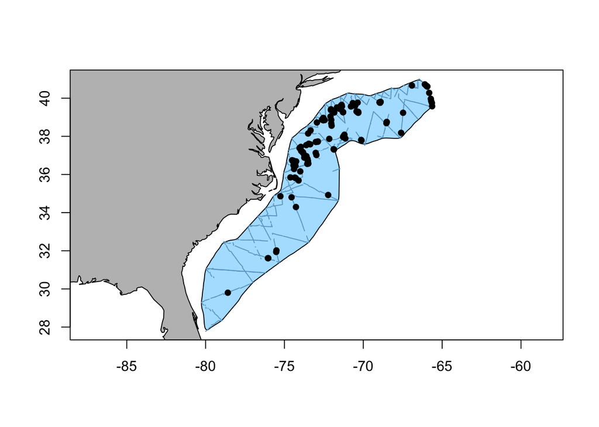

**Fig. 1:** Distribution of sperm whale (*Physeter macrocephalus*) sightings within the study area off the US East coast. Surveyed transects are shown as solid lines.

```r
#'---------------------------------------------
# Create an outline of the study area boundaries
#'---------------------------------------------

study_area <- predgrid[, c("x", "y")]
study_area$value <- 1
study_area <- raster::rasterFromXYZ(study_area, crs = sp::CRS("+proj=aea +lat_1=38 +lat_2=30 +lat_0=34 +lon_0=-73 +x_0=0 +y_0=0 +datum=WGS84 +units=m +no_defs +ellps=WGS84 +towgs84=0,0,0"))
study_area <- raster::rasterToPolygons(study_area, dissolve = TRUE)
study_area <- sp::spTransform(study_area, CRSobj = sp::proj4string(transects))
study_area <- smoothr::smooth(study_area, method = "ksmooth", smoothness = 5)

#'---------------------------------------------
# Produce a simple plot
#'---------------------------------------------

plot(study_area, col = "lightskyblue1") # Region boundary
plot(transects, add = TRUE, col = "skyblue3") # Survey tracks
maps::map("world", fill = TRUE, col = "grey",
          xlim = range(obs$coords.x1),
          ylim = range(obs$coords.x2), add = TRUE)
pts <- obs # Sightings
coordinates(pts) <- ~ coords.x1 + coords.x2
axis(1); axis(2); box()
points(pts, pch = 16)
```

### Analysis

First, we define the projected coordinate system appropriate to the study area (i.e. Albers Equal Area, `+proj=aea`). Our explanatory covariates of interest are: seabed depth (`Depth`), sea surface temperature (`SST`), primary productivity (`NPP`), distance to the nearest canyons and seamounts (`DistToCAS`), and eddy kinetic energy (`EKE`) – see Roberts *et al.* (2016) for details.

```r
#'---------------------------------------------
# Define projected coordinate system
#'---------------------------------------------

aftt_crs <- sp::CRS("+proj=aea +lat_1=38 +lat_2=30 +lat_0=34 +lon_0=-73 +x_0=0 +y_0=0 +datum=WGS84 +units=m +no_defs +ellps=WGS84 +towgs84=0,0,0")

#'---------------------------------------------
# Define environmental covariates of interest
#'---------------------------------------------

covariates.spermwhale <- c("Depth", "SST", "NPP", "DistToCAS", "EKE")
```

#### Quantifying extrapolation

To assess extrapolation in environmental space, we can run the extrapolation detection (ExDet) tool proposed by Mesgaran *et al.* (2014) using the function `compute_extrapolation`. Note that this tool was originally implemented in the [`ecospat`](https://cran.r-project.org/src/contrib/Archive/ecospat/) package, although with more limited capabilities.

The following arguments are required:

- `segments`: reference data
- `covariate.names`: names of covariates of interest
- `prediction.grid`: target data
- `coordinate.system`: projected coordinate system relevant to study location
- `print.summary`: if `TRUE`, prints a summary of the results in the R console
- `print.precision`: number of significant figures printed in the summary
- `save.summary`: if `TRUE`, saves summary to the function’s output object

Here, we store the results in an object called `spermwhale.extrapolation`. Values are expressed as both the number (`n`) of grid cells subject to extrapolation, and the proportion (`%`) of the target system that this represents.

```r
spermwhale.extrapolation <- compute_extrapolation(segments = segs,
                                   covariate.names = covariates.spermwhale,
                                   prediction.grid = predgrid,
                                   coordinate.system = aftt_crs,
                                   print.summary = TRUE,
                                   save.summary = FALSE,
                                   print.precision = 2)
```

```
##
##
## Table: Extrapolation
##
## --------------  ------------  ------------
## Analogue        n = 5,175     97.92 %
## -----------     -----------   -----------
## Univariate      n = 65        1.23 %
## Combinatorial   n = 45        0.85 %
## -----------     -----------   -----------
## Sub-total       n = 110       2.08 %
## -----------     -----------   -----------
## Total           n = 5,285     100 %
## --------------  ------------  ------------
##
##
## Table: Most influential covariates (MIC)
##
## --------------  ------------  ------------  ------------
## Univariate      EKE           n = 24        0.45 %
## Univariate      SST           n = 17        0.32 %
## Univariate      Depth         n = 16        0.3 %
## Univariate      NPP           n =  6        0.11 %
## Univariate      DistToCAS     n =  2        0.04 %
## -----------     -----------   -----------   -----------
## Sub-total                     n = 65        1.23 %
## -----------     -----------   -----------   -----------
## Combinatorial   NPP           n = 39        0.74 %
## Combinatorial   Depth         n =  6        0.11 %
## -----------     -----------   -----------   -----------
## Sub-total                     n = 45        0.85 %
## -----------     -----------   -----------   -----------
## Total                         n = 110       2.08 %
## --------------  ------------  ------------  ------------
```

In this example, the vast majority of prediction grid cells (n = 5,175 – i.e. 97.92%) are characterised by environmental conditions (defined along the axes of the covariates specified above) similar (aka ‘analogue’) to those captured in the original sample (`segs`). A quick check reveals that those results align with our expectations from the data in `predgrid`.

```r
# Number of cells subject to univariate extrapolation (see below for definition)
predgrid %>%
  dplyr::filter(!dplyr::between(Depth, min(segs$Depth), max(segs$Depth)) |
                  !dplyr::between(SST, min(segs$SST), max(segs$SST)) |
                  !dplyr::between(NPP, min(segs$NPP), max(segs$NPP)) |
                  !dplyr::between(DistToCAS, min(segs$DistToCAS), max(segs$DistToCAS)) |
                  !dplyr::between(EKE, min(segs$EKE), max(segs$EKE))) %>%
  nrow()
```

```
## [1] 65
```

In practice, `compute_extrapolation` returns a list containing both `data.frames` (extrapolation values) and `rasters` (spatial representation of these values), with the following structure:

```r
tibble::glimpse(spermwhale.extrapolation)
```

```
## List of 2
##  $ data   :List of 4
##   ..$ all          :'data.frame':    5285 obs. of  6 variables:
##   .. ..$ x                : num [1:5285] 547985 557985 527985 537985 547985 ...
##   .. ..$ y                : num [1:5285] 788254 788254 778254 778254 778254 ...
##   .. ..$ ExDet            : num [1:5285] -0.1067 -0.0587 -0.0532 -0.0337 0.3445 ...
##   .. ..$ mic_univariate   : int [1:5285] 2 2 2 2 NA NA NA 2 2 NA ...
##   .. ..$ mic_combinatorial: int [1:5285] NA NA NA NA NA NA NA NA NA NA ...
##   .. ..$ mic              : num [1:5285] 2 2 2 2 0 0 0 2 2 0 ...
##   ..$ univariate   :'data.frame':    65 obs. of  6 variables:
##   .. ..$ x                : num [1:65] 547985 557985 527985 537985 507985 ...
##   .. ..$ y                : num [1:65] 788254 788254 778254 778254 768254 ...
##   .. ..$ ExDet            : num [1:65] -0.1067 -0.0587 -0.0532 -0.0337 -0.0394 ...
##   .. ..$ mic_univariate   : int [1:65] 2 2 2 2 2 2 2 2 2 2 ...
##   .. ..$ mic_combinatorial: int [1:65] NA NA NA NA NA NA NA NA NA NA ...
##   .. ..$ mic              : num [1:65] 2 2 2 2 2 2 2 2 2 2 ...
##   ..$ combinatorial:'data.frame':    45 obs. of  6 variables:
##   .. ..$ x                : num [1:45] 557985 567985 577985 587985 607985 ...
##   .. ..$ y                : num [1:45] 728254 728254 728254 728254 728254 ...
##   .. ..$ ExDet            : num [1:45] 1.11 1.09 1.45 1.44 1.19 ...
##   .. ..$ mic_univariate   : int [1:45] NA NA NA NA NA NA NA NA NA NA ...
##   .. ..$ mic_combinatorial: int [1:45] 3 3 3 3 3 3 3 3 3 3 ...
##   .. ..$ mic              : num [1:45] 3 3 3 3 3 3 3 3 3 3 ...
##   ..$ analogue     :'data.frame':    5175 obs. of  6 variables:
##   .. ..$ x                : num [1:5175] 547985 557985 567985 527985 537985 ...
##   .. ..$ y                : num [1:5175] 778254 778254 778254 768254 768254 ...
##   .. ..$ ExDet            : num [1:5175] 0.344 0.263 0.212 0.346 0.279 ...
##   .. ..$ mic_univariate   : int [1:5175] NA NA NA NA NA NA NA NA NA NA ...
##   .. ..$ mic_combinatorial: int [1:5175] NA NA NA NA NA NA NA NA NA NA ...
##   .. ..$ mic              : num [1:5175] 0 0 0 0 0 0 0 0 0 0 ...
##  $ rasters:List of 2
##   ..$ ExDet:List of 4
##   .. ..$ all          :Formal class 'RasterLayer' [package "raster"] with 12 slots
##   .. ..$ univariate   :Formal class 'RasterLayer' [package "raster"] with 12 slots
##   .. ..$ combinatorial:Formal class 'RasterLayer' [package "raster"] with 12 slots
##   .. ..$ analogue     :Formal class 'RasterLayer' [package "raster"] with 12 slots
##   ..$ mic  :List of 4
##   .. ..$ all          :Formal class 'RasterLayer' [package "raster"] with 12 slots
##   .. ..$ univariate   :Formal class 'RasterLayer' [package "raster"] with 12 slots
##   .. ..$ combinatorial:Formal class 'RasterLayer' [package "raster"] with 12 slots
##   .. ..$ analogue     :Formal class 'RasterLayer' [package "raster"] with 12 slots
```

Three types of extrapolation can be identified (**Figure 2**):

- **Univariate** extrapolation occurs when `ExDet` values < 0. This is also known as *mathematical*, *strict*, or *Type 1* extrapolation, and represents conditions outside the range of individual covariates in the reference sample.
- **Combinatorial** extrapolation occurs when `ExDet` values > 1. This is also known as *multivariate* or *Type 2* extrapolation, and describes novel combinations of values encountered within the univariate range of reference covariates. Such combinations are identified based on the Mahalanobis distance metric (D<sup>2</sup>), a well-known and scale-invariant measure of multivariate outliers (Rousseeuw and Zomeren 1990).
- Lastly, values between 0 and 1 denote predictions made in **analogue** conditions. These correspond to what is commonly referred to as *interpolation*, although if found in a different region in space or past/future period in time, then the terms *geographical/temporal* extrapolation are sometimes also used.

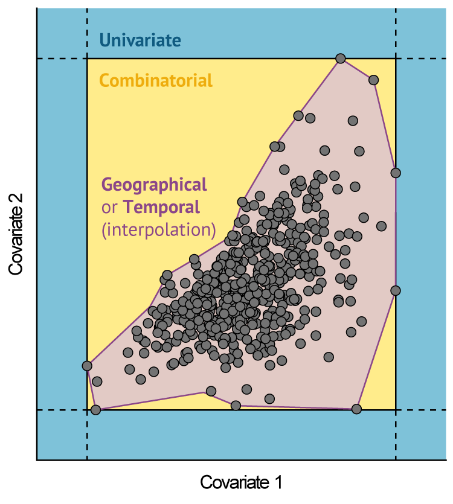

**Fig. 2:** Schematic representation of extrapolation in multivariate environmental space, based on two hypothetical covariates. Reference data points are represented as grey circles. Shaded areas correspond to different types of extrapolation outside the envelope of the reference data. Univariate extrapolation occurs beyond the range of individual covariates. Combinatorial extrapolation occurs within this range, but outside the reference hyperspace/hypervolume. Source: Bouchet *et al.* (2019), adapted from Mesgaran *et al.* (2014).

`compute_extrapolation` also determines which covariate makes the largest contribution to extrapolation for any given grid cell, i.e. the **most influential covariate** (`mic`) (Mesgaran *et al.* 2014). In univariate extrapolation, this is the covariate that leads to the highest negative univariate distance from the initial covariate range. In combinatorial extrapolation, this corresponds to the covariate whose omission (while retaining all others) makes the largest reduction in the Mahalanobis distance to the centroid of the reference data. See Mesgaran *et al.* (2014) for formulae and technical explanations.

`ExDet` values can be retrieved from the returned list, as below:

```r
# Example from combinatorial extrapolation
head(spermwhale.extrapolation$data$combinatorial)
```

```
##          x      y    ExDet mic_univariate mic_combinatorial mic
## 1 557984.6 728254 1.106042             NA                 3   3
## 2 567984.6 728254 1.090527             NA                 3   3
## 3 577984.6 728254 1.447405             NA                 3   3
## 4 587984.6 728254 1.437475             NA                 3   3
## 5 607984.6 728254 1.186687             NA                 3   3
## 6 527984.6 718254 1.240072             NA                 3   3
```

#### Summarising extrapolation

The summary table generated by `compute_extrapolation` is the result of an internal call to the function `summarise_extrapolation`. This function can also be run separately on the output of `compute_extrapolation`, if needed.

The function takes the following arguments:

- `extrapolation.object`: output from compute_extrapolation
- `covariate.names`: names of covariates of interest
- `extrapolation`: if `TRUE`, returns a summary of univariate/combinatorial extrapolation
- `mic`: if `TRUE`, returns a summary of the most influential covariates
- `print.precision`: number of significant figures printed in the summary

Note that values of the summary statistics can be saved to an object in list form (here the `summary.values` object).

```r
summary.values <- summarise_extrapolation(extrapolation.object = spermwhale.extrapolation,
                        covariate.names = covariates.spermwhale,
                        extrapolation = TRUE,
                        mic = TRUE,
                        print.precision = 2)
```

```
##
##
## Table: Extrapolation
##
## --------------  ------------  ------------
## Analogue        n = 5,175     97.92 %
## -----------     -----------   -----------
## Univariate      n = 65        1.23 %
## Combinatorial   n = 45        0.85 %
## -----------     -----------   -----------
## Sub-total       n = 110       2.08 %
## -----------     -----------   -----------
## Total           n = 5,285     100 %
## --------------  ------------  ------------
##
##
## Table: Most influential covariates (MIC)
##
## --------------  ------------  ------------  ------------
## Univariate      EKE           n = 24        0.45 %
## Univariate      SST           n = 17        0.32 %
## Univariate      Depth         n = 16        0.3 %
## Univariate      NPP           n =  6        0.11 %
## Univariate      DistToCAS     n =  2        0.04 %
## -----------     -----------   -----------   -----------
## Sub-total                     n = 65        1.23 %
## -----------     -----------   -----------   -----------
## Combinatorial   NPP           n = 39        0.74 %
## Combinatorial   Depth         n =  6        0.11 %
## -----------     -----------   -----------   -----------
## Sub-total                     n = 45        0.85 %
## -----------     -----------   -----------   -----------
## Total                         n = 110       2.08 %
## --------------  ------------  ------------  ------------
```

```r
summary.values
```

```
## $extrapolation
## $extrapolation$univariate.n
## [1] 65
##
## $extrapolation$univariate.p
## [1] 1.229896
##
## $extrapolation$combinatorial.n
## [1] 45
##
## $extrapolation$combinatorial.p
## [1] 0.8514664
##
## $extrapolation$analogue.n
## [1] 5175
##
## $extrapolation$analogue.p
## [1] 97.91864
##
##
## $mic
## $mic$Depth
## $mic$Depth$.n
## [1] 16
##
## $mic$Depth$.p
## [1] 0.3027436
##
##
## $mic$DistToCAS
## $mic$DistToCAS$.n
## [1] 2
##
## $mic$DistToCAS$.p
## [1] 0.03784295
##
##
## $mic$EKE
## $mic$EKE$.n
## [1] 24
```

[output cut: 20 more lines]

```
##
## $mic$Depth
## $mic$Depth$.n
## [1] 6
##
## $mic$Depth$.p
## [1] 0.1135289
##
##
## $mic$NPP
## $mic$NPP$.n
## [1] 39
##
## $mic$NPP$.p
## [1] 0.7379376
```

#### Comparing covariates

The extent and magnitude of extrapolation naturally vary with the type and number of covariates considered. It may be useful, therefore, to test different combinations of covariates to inform their selection *a priori*, i.e. before model fitting, to support model parsimony.

The `compare_covariates` function is available for this purpose. It is designed to assess extrapolation iteratively for all combinations of `n.covariates`, and returns an overview of those that minimise/maximise extrapolation (as measured by the number of grid cells subject to extrapolation in the prediction area).

`n.covariates` can be supplied as any vector of integers from 1 to `p`, where `p` is the total number of covariates available. Its default value of `NULL` is equivalent to `1:p`, meaning that all possible combinations are tested, unless otherwise specified.

Additional arguments include:

- `extrapolation.type`: one of `'univariate'`, `'combinatorial'` or `'both'`
- `segments`: reference data
- `covariate.names`: names of covariates of interest
- `prediction.grid`: target data
- `coordinate.system`: projected coordinate system relevant to study location
- `create.plots`: if `TRUE`, generates boxplots of results
- `display.percent`: if `TRUE`, the y-axis of the boxplots is expressed as a percentage of the total number of grid cells in `prediction.grid`

Below is an example for both types of extrapolation (univariate and combinatorial), and the full set of five covariates.

```
## Computing ...
```

```
## Creating summaries ...
```

```
## Done!
```

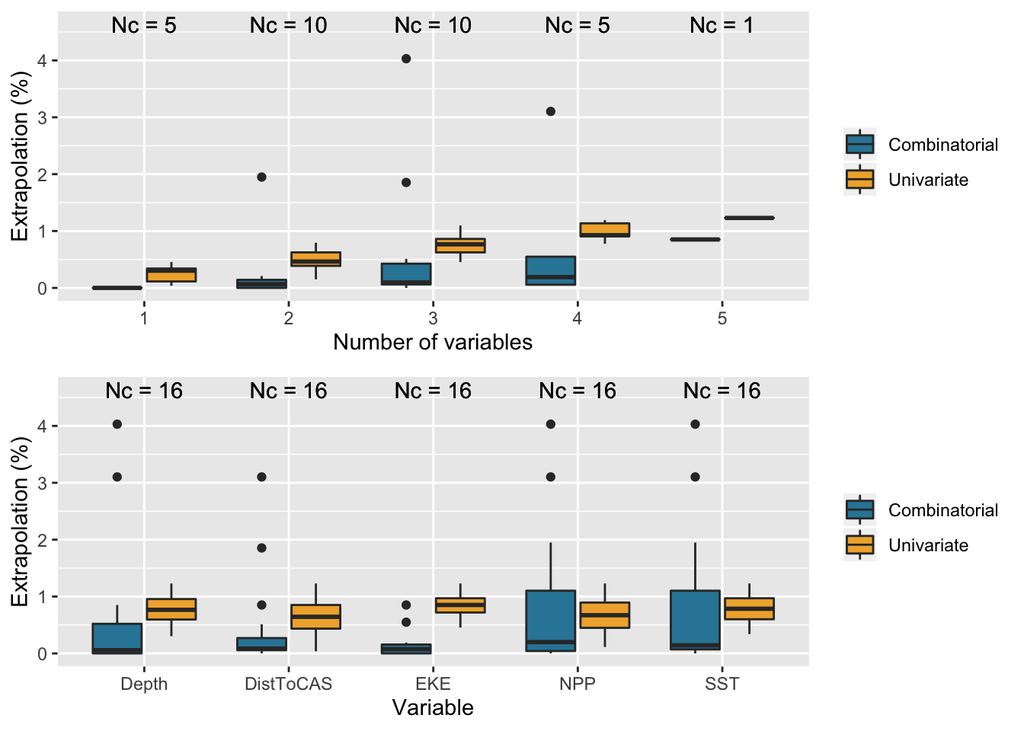

```
##
##
## Extrapolation   Minimum             n_min  Maximum                           n_max
## --------------  -----------------  ------  --------------------------------  ------
## Univariate      DistToCAS               2  Depth, SST, NPP, DistToCAS, EKE   65
## Combinatorial   Depth                   0  Depth, SST, NPP                   213
##                 SST                     0  -                                 -
##                 NPP                     0  -                                 -
##                 DistToCAS               0  -                                 -
##                 EKE                     0  -                                 -
##                 Depth, DistToCAS        0  -                                 -
##                 Depth, EKE              0  -                                 -
##                 NPP, DistToCAS          0  -                                 -
##                 NPP, EKE                0  -                                 -
##                 Depth, SST, EKE         0  -                                 -
##                 Depth, NPP, EKE         0  -                                 -
## Both            DistToCAS               2  Depth, SST, NPP                   252
```

```r
compare_covariates(extrapolation.type = "both",
                   covariate.names = covariates.spermwhale,
                   n.covariates = NULL,
                   segments = segs,
                   prediction.grid = predgrid,
                   coordinate.system = aftt_crs,
                   create.plots = TRUE,
                   display.percent = TRUE)
```

The top graph summarises the extent of univariate (yellow) and combinatorial (blue) extrapolation for all combinations of $1, 2, ..., n$ covariates. The total number of combinations is given above each boxplot as $N_c$. As expected, univariate extrapolation increases with the number of covariates considered.

The bottom graph displays the same results, summarised by covariate of interest. This may help identify any covariates that consistently lead to extrapolation, and should be avoided. Here, none of the covariates stand out as driving extrapolation more than any others, although combinatorial extrapolation is marginally more prevalent with `NPP` and `SST`.

#### Finding nearby data

While extrapolation is often seen as a binary concept (i.e. it either does or does not take place), it is reasonable to expect that predictions made at target points situated just outside the sampled environmental space may be more reliable than those made at points far outside it. The ExDet tool available through `compute_extrapolation` inherently quantifies this notion of ‘distance’ from the envelope (solid line) of the reference data (grey circles) (**Figure 3A**).

However, the multivariate distribution of reference data points is often far from homogeneous. It is possible, therefore, for target points representing analogue conditions to fall within sparsely sampled regions of the reference space; or conversely, for two target points reflecting an equal degree of extrapolation to have very different amounts of reference data within their vicinity (Virgili *et al.* 2017; Mannocci *et al.* 2018).

An example of this is shown in **Figure 3B**, where three target points $x_1$, $x_2$ and $x_3$ are located equally close to the envelope of the reference data. In essence, these reflect identical degrees of extrapolation, as defined under the ExDet framework. However, given the shape of the data cloud in multivariate space, it is clear that predictions made at target point $x_1$ will far ‘better informed’ by the sample than those made at $x_2$ or $x_3$, as a bigger cluster of reference points lies in their vicinity (green circle around $x_1$).

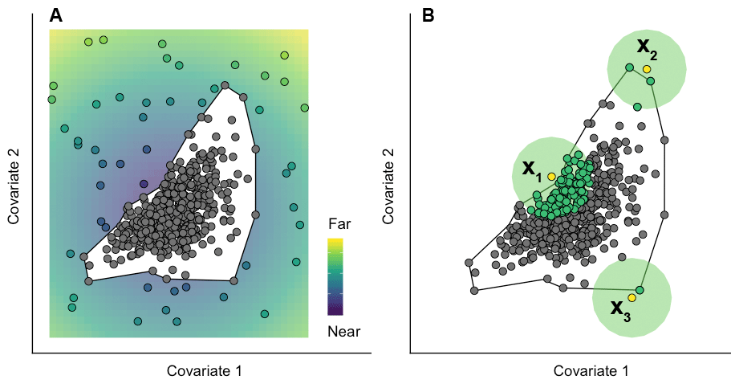

**Fig. 3:** Conceptual representation of two key extrapolation metrics. (A) Distance from the sampled environmental space. A target point far from the envelope of the reference data (eg. falling in the yellow area) is arguably ‘more of an extrapolation’ than one close to it (eg. falling in the purple area). (B) Neighbourhood (syn. percentage of data nearby). Due to the shape of the reference data cloud, the amount of sample information available to ‘inform’ predictions made at target points can vary considerably. Source: Bouchet *et al.* (2019).

The notion of **neighbourhood** (or **percentage/proportion of data nearby**, hereafter `%N`) captures this very idea, and provides an additional measure of the reliability of extrapolations in multivariate environmental space (Virgili *et al.* 2017; Mannocci *et al.* 2018). In practice, `%N` for any target point is taken as the proportion of reference data within a radius of one geometric mean Gower’s distance (G<sup>2</sup>, calculated between all pairs of reference points) of that point (King and Zeng 2007). The Gower’s distance between two points $i$ and $j$ defined along the axes of $K$ covariates is calculated as the average absolute distance between the values of these two points in each dimension, divided by the range of the data, such that:

$$G_{ij}^2=\frac{1}{K}\sum_{k=1}^{K}\frac{\left|x_{ik}-x_{jk}\right|}{\textrm{max}(X_k)-\textrm{min}(X_k)}$$

The `compute_nearby` function is adapted from the code given in Mannocci *et al.* (2018), and allows the calculation of Gower’s distances (G<sup>2</sup>) as a basis for defining the neighbourhood.

The `nearby` argument to this function corresponds to the radius within which neighbouhood calculations will occur. It has a default value of `1`, as per Mannocci *et al.* (2018) and Virgili *et al.* (2017). Increasing its value (e.g. to say, `2`) would mean doubling the size of the green circles in **Figure 3B**, and would lead to larger percentages of data nearby per target point.

**Important:** The sperm whale dataset used here is sufficiently small that `compute_nearby` should run in a matter of seconds on most machines. However, applying the function to larger datasets may burn out memory allocation and lead to an R session failure. Additional arguments can be passed to `compute_nearby` to accommodate such ‘big’ data. Their use is unnecessary here, but further details can be found in the package documentation.

```r
#'---------------------------------------------
# Calculate Gower's distances and %N
#'---------------------------------------------

spermwhale.nearby <- compute_nearby(segments = segs,
                                    prediction.grid = predgrid,
                                    coordinate.system = aftt_crs,
                                    covariate.names = covariates.spermwhale,
                                    nearby = 1)
```

```
## Preprocessing data ...
```

```
## Calculating distances ....
```

```
## Calculating the geometric variance...
```

```
## Calculating cumulative frequencies ...
```

```
## Finishing up ...
```

```
## Done!
```

#### Visualising extrapolation

Lastly, we can use the `map_extrapolation` function to create a series of interactive html maps of extrapolation in the prediction area.

Arguments to this function are identical to those of `compute_extrapolation`, with the exception of:

- `map.type`: output to be shown on the map. One of `'extrapolation'` for a map of extrapolation values, `'mic'` for a map of the most influential covariates, or `'nearby'` for a neighbourhood map (proportion of reference data near each target grid cell, a.k.a `%N`).
- `extrapolation.values`: output from `compute_extrapolation` (only valid for `map.type = 'extrapolation'` and `map.type = 'mic'`)
- `gower.values`: output from `compute_nearby` (only valid for `map.type = 'nearby'`)

`sightings` and `tracks` are optional arguments, and only plotted if specified. If either is provided as a matrix, then coordinates must be labelled `x` and `y`, lest a warning be returned. Tracks can also be given as a `SpatialLinesDataFrame` object. The resulting maps can be panned, zoomed, and all layers toggled on and off independently. However, note that maps rely on the `leaflet` package (Cheng *et al.* 2018), and thus require an internet connection; they will not work offline. Facilities to save map tiles locally for offline viewing are currently not implemented but may be rolled into a future version of the code. Finally, note that `prediction.grid` is only used here to set the map extent when plotting.

```r
#'---------------------------------------------
# Rename coordinates and convert to SpatialPointsdf
#'---------------------------------------------

obs.sp <- obs %>%
  dplyr::rename(., x = coords.x1, y = coords.x2) %>%
  sp::SpatialPointsDataFrame(coords = cbind(.$x, .$y), data = ., proj4string = sp::CRS("+proj=longlat +datum=WGS84 +no_defs +ellps=WGS84 +towgs84=0,0,0")) %>%
  sp::spTransform(., CRSobj = aftt_crs)
```

Here’s a map of extrapolation (`ExDet`) values:

```r
map_extrapolation(map.type = "extrapolation",
                  extrapolation.values = spermwhale.extrapolation,
                  covariate.names = covariates.spermwhale,
                  prediction.grid = predgrid,
                  coordinate.system = aftt_crs,
                  sightings = obs.sp,
                  tracks = transects)
```

[interactive chart not shown]

Most influential covariates (MIC):

```r
map_extrapolation(map.type = "mic",
                  extrapolation.values = spermwhale.extrapolation,
                  covariate.names = covariates.spermwhale,
                  prediction.grid = predgrid,
                  coordinate.system = aftt_crs,
                  sightings = obs.sp,
                  tracks = transects)
```

[interactive chart not shown]

Proportion of data nearby (`%N`):

```r
map_extrapolation(map.type = "nearby",
                  gower.values = spermwhale.nearby,
                  covariate.names = covariates.spermwhale,
                  prediction.grid = predgrid,
                  coordinate.system = aftt_crs,
                  sightings = obs.sp,
                  tracks = transects)
```

[interactive chart not shown]

#### Full analysis

For simplicity, all the above analyses can be performed in a single step by calling the wrapper function `extrapolation_analysis`. Most arguments are derived from the individual functions presented above, and should thus be self-explanatory. Note, however, that specific parts of the analysis can be run/bypassed using the following arguments:

- `summarise.extrapolation`: if `TRUE`, run `summarise_extrapolation`
- `compare.covariates` = if `TRUE`, run `compare_covariates`
- `nearby.compute` = if `TRUE`, run `compute_nearby`
- `map.generate` = if `TRUE`, run `map_extrapolation`

```r
#'---------------------------------------------
# One function to rule them all, one funtion to find them,
# One function to bring them all, and in the darkness bind them.
#'---------------------------------------------

spermwhale.analysis <- extrapolation_analysis(segments = segs,
                                          covariate.names = covariates.spermwhale,
                                          prediction.grid = predgrid,
                                          coordinate.system = aftt_crs,
                                          summarise.extrapolation = TRUE,
                                          summary.print.precision = 2,
                                          compare.covariates = TRUE,
                                          compare.extrapolation.type = "both",
                                          compare.n.covariates = NULL,
                                          compare.create.plots = TRUE,
                                          compare.display.percent = TRUE,
                                          nearby.compute = TRUE,
                                          nearby.nearby = 1,
                                          map.generate = TRUE,
                                          map.sightings = obs.sp,
                                          map.tracks = transects)
```

Results are packaged in a `list` object with three levels, i.e. `extrapolation`, `nearby`, and `maps`, representing the outputs of each step in the analysis.

## Conclusion

This vignette has outlined the steps need to quantify extrapolation in environmental space using the `dsmextra` R package. Note that many possible models (and model types) can be fitted to distance sampling or related data, each potentially behaving differently outside reference conditions for any given level of extrapolation (Yates *et al.* 2018). Because of this, the tools presented herein are model-agnostic and only designed to provide an *a priori* assessment. This may, in turn, help inform modelling decisions and model interpretations, but caution should always be exercised when performing model selection, discrimination and criticism.

## References

Bouchet PJ, Miller DL, Harris CM, Thomas L (2019). From here and now to there and then: Practical recommendations for the extrapolation of cetacean density surface models to novel conditions. CREEM Technical report 2019-01. University of St Andrews, St Andrews. Available at: https://research-repository.st-andrews.ac.uk/handle/10023/18509

Broennimann O, Di Cola V, Guisan A (2016). ‘Ecospat: Spatial ecology miscellaneous methods. R package version 2.1.1’. Available at: https://CRAN.R-project.org/package=ecospat

Cheng J, Karambelkar B, Xie Y (2018). ‘Leaflet: Create interactive web maps with the javascript ’leaflet’ library. R package version 2.0.2.’ Available at: https://CRAN.R-project.org/package=leaflet

Gandrud C, King G, Stoll H, Zeng L (2017). ‘WhatIf: Evaluate counterfactuals. R package version 1.5-9.’ Available at: https://CRAN.R-project.org/package=WhatIf

King G, Zeng L (2007). When can history be our guide? The pitfalls of counterfactual inference. *International Studies Quarterly* **51**, 183–210. DOI: 10.1111/j.1468-2478.2007.00445.x

Mannocci L, Roberts JJ, Halpin PN, Authier M, Boisseau O, Bradai MN, Canãdas A, Chicote C, David L, Di-Méglio N, Fortuna CM, Frantzis A, Gazo M, Genov T, Hammond PS, Holcer D, Kaschner K, Kerem D, Lauriano G, Lewis T, Notarbartolo Di Sciara G, Panigada S, Raga JA, Scheinin A, Ridoux V, Vella A, Vella J (2018). Assessing cetacean surveys throughout the mediterranean sea: A gap analysis in environmental space. *Scientific Reports* **8**, art3126. DOI: 10.5061/dryad.4pd33

Mannocci L, Roberts JJ, Miller DL, Halpin PN (2017). Extrapolating cetacean densities to quantitatively assess human impacts on populations in the high seas. *Conservation Biology* **31**, 601–614. DOI: 10.1111/cobi.12856

Mesgaran MB, Cousens RD, Webber BL (2014). Here be dragons: A tool for quantifying novelty due to covariate range and correlation change when projecting species distribution models. *Diversity and Distributions* **20**, 1147–1159. DOI: 10.1111/ddi.12209

Miller DL, Burt ML, Rexstad EA, Thomas L (2013). Spatial models for distance sampling data: Recent developments and future directions. *Methods in Ecology and Evolution* **4**, 1001–1010. DOI: 10.1111/2041-210X.12105

Miller DL, Rexstad E, Burt L, Bravington MV, Hedley. S (2015). ‘Dsm: Density surface modelling of distance sampling data. R package version 2.2.9.’ Available at: https://CRAN.R-project.org/package=dsm

Roberts JJ, Best BD, Mannocci L, Fujioka E, Halpin PN, Palka DL, Garrison LP, Mullin KD, Cole TVN, Khan CB, McLellan WA, Pabst DA, Lockhart GG (2016). Habitat-based cetacean density models for the u.s. Atlantic and gulf of mexico. *Scientific Reports* **6**, art22615. DOI: 10.1038/srep22615

Rousseeuw PJ, Zomeren BC van (1990). Unmasking multivariate outliers and leverage points. *Journal of the American Statistical Association* **85**, 633–639. DOI: 10.1080/01621459.1990.10474920

Sequeira A, Bouchet PJ, Yates K, Mengersen K, Caley J (2018). Transferring biodiversity models for conservation: Opportunities and challenges. *Methods in Ecology and Evolution* **9**, 1250–1264. DOI: 10.1111/2041-210X.12998

Virgili A, Racine M, Authier M, Monestiez P, Ridoux V (2017). Comparison of habitat models for scarcely detected species. *Ecological Modelling* **346**, 88–98. DOI: 10.1016/j.ecolmodel.2016.12.013

Yates KL, Bouchet PJ, Caley MJ, Mengersen K, Randin CF, Parnell S, Fielding AH, Bamford AJ, Ban S, Barbosa AM, Dormann CF, Elith J, Embling CB, Ervin GN, Fisher R, Gould S, Graf RF, Gregr EJ, Halpin PN, Heikkinen RK, Heinänen S, Jones AR, Krishnakumar PK, Lauria V, Lozano-Montes H, Mannocci L, Mellin C, Mesgaran MB, Moreno-Amat E, Mormede S, Novaczek E, Oppel S, Ortuño Crespo G, Peterson AT, Rapacciuolo G, Roberts JJ, Ross RE, Scales KL, Schoeman D, Snelgrove P, Sundblad G, Thuiller W, Torres LG, Verbruggen H, Wang L, Wenger S, Whittingham MJ, Zharikov Y, Zurell D, Sequeira AMM (2018). Outstanding challenges in the transferability of ecological models. *Trends in Ecology and Evolution* **33**, 790–802. DOI: 10.1016/j.tree.2018.08.001